# Etude du DPE et des consommations électriques de logements type appartements à Lyon vs Lille

HO Huy, TRAN Cloélia

16-11-2025

## Introduction : Contexte de l’étude

#### Analyse comparative des consommations électriques selon le DPE des logements type appartement à Lyon et Lille

La performance énergétique d’un logement, mesurée par le Diagnostic de Performance Énergétique (DPE), constitue un indicateur clé de sa consommation d’énergie.

Dans le cadre de ce projet, il s’agira d’analyser dans quelle mesure la classe énergétique influence les consommations électriques moyennes des appartements situés à Lyon et Lille, en distinguant les logements neufs des logements anciens.

À partir de données réelles sur les DPE et les consommations, l’objectif est de mettre en évidence les écarts de performance selon le type de logement et la localisation, à l’aide d’analyses statistiques et de visualisations produites avec R.

### 1. Répartition des Étiquettes DPE pour Lyon et Lille

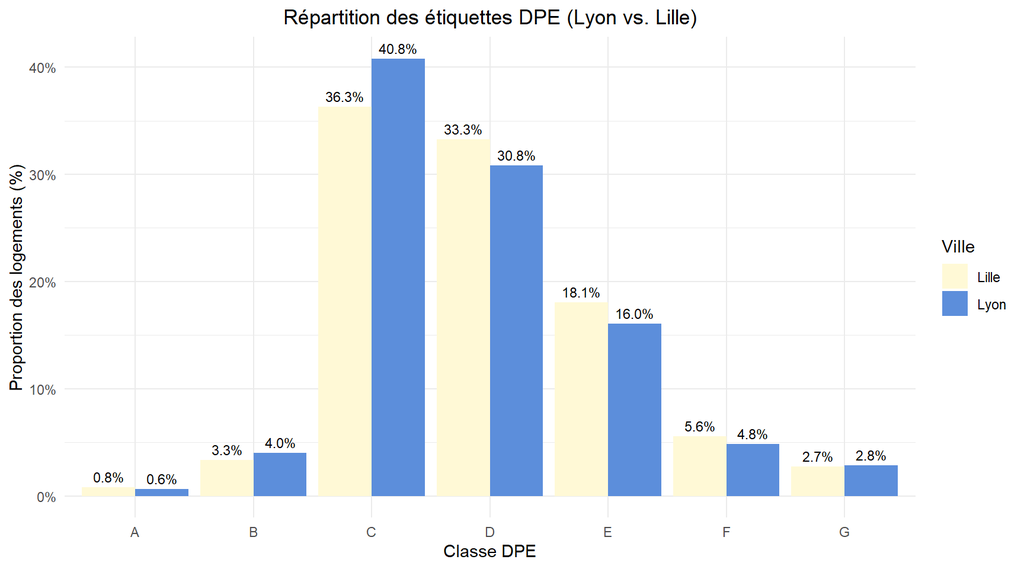

Ce graphique nous montre que la classe C représente la plus grande proportion de logements à Lyon et à Lille. En revanche, on observe que Lille possède plus de logements classés D, E, F que Lyon, ce qui pourrait signaler un défi plus important de rénovation énergétique à Lille.

L’analyse montre aussi l’ensemble des logements de Lille présente un **taux de passoires** (F+G) de 8.3% légèrement supérieur à celui de Lyon (7.6%). Cet écart, combiné à une plus forte proportion de classes D et E à Lille, confirme un défi de rénovation énergétique légèrement plus important dans la métropole du Nord.

## 2. Part de l’électricité dans le chauffage

Notre étude se concentre sur les consommations *électriques*. Nous vérifions donc la part de cette énergie dans le chauffage principal des deux villes.

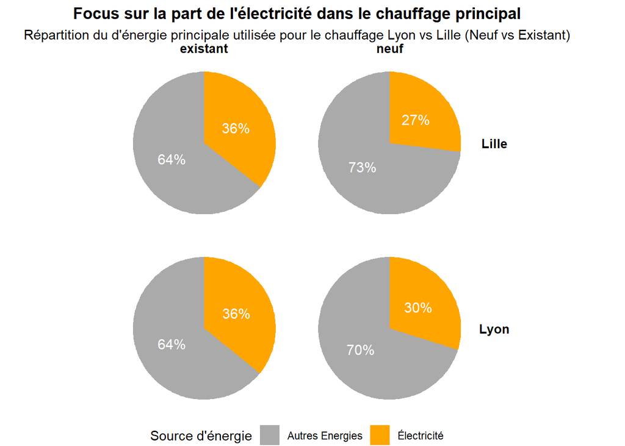

**Intrerprétation :** L’ensemble des appartements **existants** à Lyon et à Lille présentent une situation identique en matière de chauffage électrique : dans chacune des deux villes, **36 %** des logements existants utilisent l’électricité comme source principale de chauffage.

Si l’ensemble des appartements existants sont identiques, les constructions **neuves** montrent un net recul de cette énergie. Cette tendance est plus forte à Lille, où la part de l’électricité chute à 27%, contre 30% à Lyon. Cela suggère que les nouvelles constructions s’orientent davantage vers d’autres solutions (gaz, réseaux de chaleur) pour répondre aux normes de performance.

## 3. Coût total moyen par m² (Logements Existants)

Nous comparons maintenant le coût énergétique *total* (tous usages, toutes énergies) pour les logements existants.

#### Résultats pour Lyon

Consommation Énergétique Moyenne par m² (Logements Existants) à Lyon

| flag | etiquette_dpe | conso_m2_moy |
| --- | --- | --- |
| existant | A | 6.345171 |
| existant | B | 8.363975 |
| existant | C | 12.925116 |
| existant | D | 18.581566 |
| existant | E | 24.399287 |
| existant | F | 31.453144 |
| existant | G | 49.093982 |

#### Résultats pour Lille

Consommation Énergétique Moyenne par m² (Logements Existants) à Lille

| flag | etiquette_dpe | conso_m2_moy |
| --- | --- | --- |
| existant | A | 5.836302 |
| existant | B | 8.551393 |
| existant | C | 13.269071 |
| existant | D | 18.871631 |
| existant | E | 24.766615 |
| existant | F | 31.265437 |
| existant | G | 44.413109 |

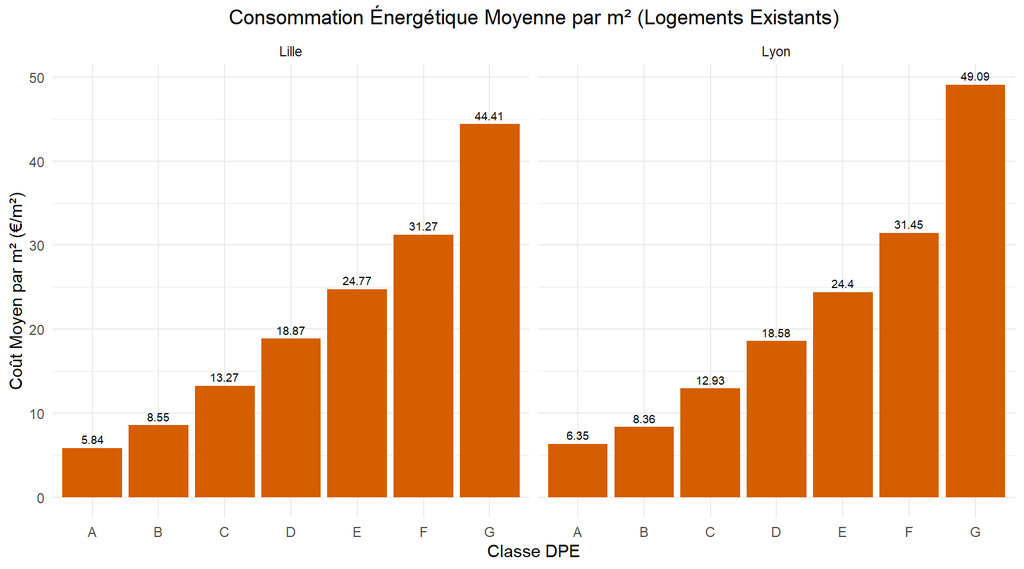

**Interprétation :** Le graphique illustre la forte corrélation entre le DPE et le coût au m². De manière surprenante, bien que le climat de Lille soit plus rigoureux, le coût moyen d’un appartement ‘G’ existant est plus élevé à Lyon (49,09 €/m²) qu’à Lille (44,41 €/m²). En revanche, les coûts pour la classe ‘F’ sont presque identiques dans les deux villes (environ 31,36 €/m²)

## 4. Coût du chauffage ÉLECTRIQUE par m² (Logements Existants)

L’analyse précédente mélangeait toutes les énergies. Nous isolons maintenant les **36% d’appartements existants chauffés à l’électricité** pour comparer leur coût de *chauffage* au m².

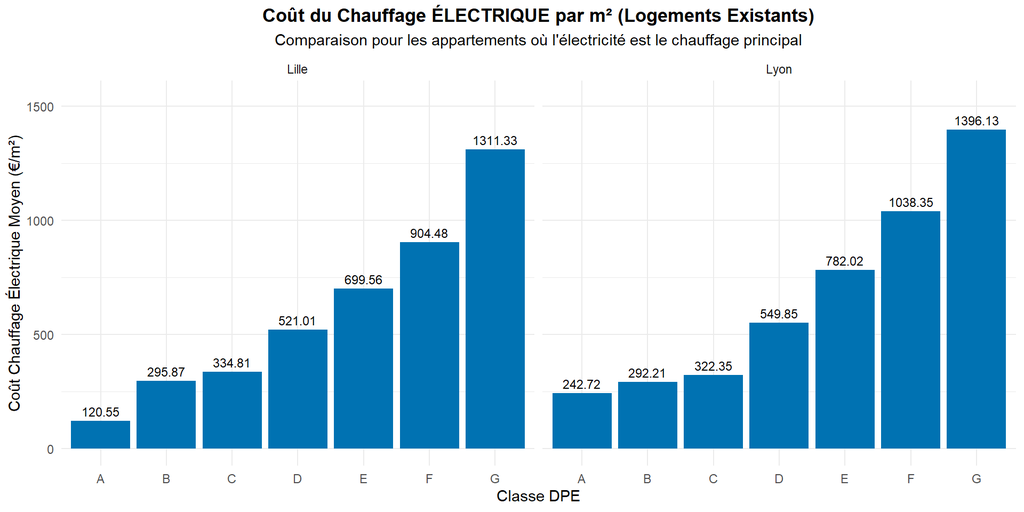

### Interprétation des coûts du chauffage électrique

L’analyse ciblée du coût moyen de chauffage au m² pour les appartements existants chauffés à l’électricité fournit deux enseignements majeurs.

#### 1. Une corrélation claire entre DPE et coût

Le graphique confirme une **corrélation positive très nette** entre l’étiquette DPE et le coût moyen du chauffage électrique. Pour les deux métropoles, la tendance est univoque : à mesure que la performance énergétique se dégrade (de A vers G), le coût s’accroît de manière exponentielle.

#### 2. Un constat surprenant : Lyon plus coûteuse que Lille

Le résultat principal de cette analyse est contraire aux attentes initiales. Malgré un climat continental plus rigoureux à Lille (nécessitant théoriquement plus de chauffage), le coût moyen du chauffage électrique pour les “passoires thermiques” (classes F et G) est **systématiquement plus élevé à Lyon**.

- Pour la **classe G**, le coût moyen lyonnais atteint **1396,13 €/m²**, contre **1311,33 €/m²** à Lille.
- L’écart est encore plus significatif pour la **classe F**, où Lyon affiche un coût de **1038,35 €/m²** contre **904,48 €/m²** à Lille, soit un surcoût d’environ 15 %.
- Cette tendance d’un coût supérieur à Lyon se vérifie pour toutes les classes de D à G.

#### 3. Conclusion et Hypothèses

L’idée selon laquelle *un climat plus froid entraîne forcément une facture plus élevée* ne se vérifie pas ici. Le coût moyen supérieur observé à Lyon laisse penser que, pour les logements chauffés à l’électricité, **la qualité moyenne du bâti** (isolation, ponts thermiques, ancienneté ou type de chauffage électrique) est sans doute moindre à Lyon qu’à Lille, notamment dans les classes énergétiques les plus faibles.

**Note méthodologique** : Les coûts moyens dépassant 1300 €/m² pour la classe G sont très élevés et probablement influencés par des valeurs extrêmes (outliers). Malgré cela, selon la moyenne, Lyon reste la ville présentant les coûts les plus élevés pour les classes F et G.